# Actividad_7_Equipo06_ Analisis_Exploratorio_de_Datos

```r
library(tidyverse)
```

```r
library(ggplot2)
```

#Lectura de datos 1

```r
datos1 <- read.csv("DatosLimpios.csv")
```

#Resumen de Categorías disponibles y resumen de algunos datos

```r
summary(datos1)
```

```
##  punto_de_venta        fecha                mes             anio
##  Length:102530      Length:102530      Min.   : 1.00   Min.   :2018
##  Class :character   Class :character   1st Qu.: 6.00   1st Qu.:2018
##  Mode  :character   Mode  :character   Median : 8.00   Median :2018
##                                        Mean   : 7.59   Mean   :2018
##                                        3rd Qu.:10.00   3rd Qu.:2018
##                                        Max.   :12.00   Max.   :2019
##    num_ventas     sku               marca              gamma
##  Min.   :1    Length:102530      Length:102530      Length:102530
##  1st Qu.:1    Class :character   Class :character   Class :character
##  Median :1    Mode  :character   Mode  :character   Mode  :character
##  Mean   :1
##  3rd Qu.:1
##  Max.   :1
##  costo_promedio      zona              estado             ciudad
##  Min.   :12509   Length:102530      Length:102530      Length:102530
##  1st Qu.:14344   Class :character   Class :character   Class :character
##  Median :14869   Mode  :character   Mode  :character   Mode  :character
##  Mean   :16681
##  3rd Qu.:19424
##  Max.   :24371
##     latitud         longitud
##  Min.   :14.87   Min.   :-117.12
##  1st Qu.:19.35   1st Qu.:-101.21
##  Median :19.53   Median : -99.23
##  Mean   :21.00   Mean   :-100.15
##  3rd Qu.:21.10   3rd Qu.: -99.12
##  Max.   :32.67   Max.   : -10.74
```

#Visualizar los datos y categorías limpias para empezar a enfocarnos en datos en especifico a partir de preguntas.

```r
str(datos1)
```

```
## 'data.frame':    102530 obs. of  14 variables:
##  $ punto_de_venta: chr  "1 poniente" "1 poniente" "1 poniente" "1 poniente" ...
##  $ fecha         : chr  "15/06/2018" "06/07/2018" "07/07/2018" "13/07/2018" ...
##  $ mes           : int  6 7 7 7 7 7 8 9 11 11 ...
##  $ anio          : int  2018 2018 2018 2018 2018 2018 2018 2018 2018 2018 ...
##  $ num_ventas    : int  1 1 1 1 1 1 1 1 1 1 ...
##  $ sku           : chr  "N.IPX64G" "N.IP864RJ" "N.IPX64P" "N.IP864G" ...
##  $ marca         : chr  "apple" "apple" "apple" "apple" ...
##  $ gamma         : chr  "premium" "alta" "premium" "alta" ...
##  $ costo_promedio: num  18278 12682 18284 12540 18278 ...
##  $ zona          : chr  "centro sur" "centro sur" "centro sur" "centro sur" ...
##  $ estado        : chr  "puebla" "puebla" "puebla" "puebla" ...
##  $ ciudad        : chr  "tehuacan" "tehuacan" "tehuacan" "tehuacan" ...
##  $ latitud       : num  18.5 18.5 18.5 18.5 18.5 ...
##  $ longitud      : num  -97.4 -97.4 -97.4 -97.4 -97.4 ...
```

#¿Cuántos tipos de gamas tenemos?

```r
gamas <- datos1 %>%
select(gamma) %>%
arrange(gamma) %>%
unique()
gamas
```

```
##         gamma
## 1        alta
## 53769 premium
```

#¿En qué ciudades tenemos ventas?

```r
ciudades <- datos1 %>%
select(ciudad) %>%
arrange(ciudad) %>%
unique()
ciudades
```

```
##                                     ciudad
## 1                                 acambaro
## 12                                acapulco
## 865                    adolfo lopez mateos
## 1032                            agua dulce
## 1051                        aguascalientes
## 2057                               allende
## 2085                            apatzingan
## 2136                               apizaco
## 2272                               apodaca
## 2299                               arandas
## 2420                           atlacomulco
## 2498                               atlixco
## 2542                    atotonilco el alto
## 2549                             azcatepec
```

[output cut: 206 more lines]

#Zonas en donde hay sucursales

```r
zonas <- datos1 %>%
select(zona) %>%
arrange(zona) %>%
unique()
zonas
```

```
##                       zona
## 1         centro occidente
## 18060           centro sur
## 70296      golfo de mexico
## 75441              noreste
## 83982             noroeste
## 90034                norte
## 96242         pacifico sur
## 98865 peninsula de yucatan
```

```r
datos1 %>% mutate(unos=1)%>% group_by(estado)%>%summarise(Cantidad=sum(unos))
```

```
## # A tibble: 32 x 2
##    estado              Cantidad
##    <chr>                  <dbl>
##  1 aguascalientes          1006
##  2 baja california         2405
##  3 baja california sur      517
##  4 campeche                 585
##  5 cdmx                   26029
##  6 chiapas                 1126
##  7 chihuahua               1602
##  8 coahuila                2065
##  9 colima                   620
## 10 durango                  430
## # ... with 22 more rows
```

#Cantidad de ventas por ciudad

```r
datos1 %>% mutate(unos=1)%>% group_by(ciudad)%>%summarise(Cantidad=sum(unos))
```

```
## # A tibble: 220 x 2
##    ciudad              Cantidad
##    <chr>                  <dbl>
##  1 acambaro                  11
##  2 acapulco                 853
##  3 adolfo lopez mateos      167
##  4 agua dulce                19
##  5 aguascalientes          1006
##  6 allende                   28
##  7 apatzingan                51
##  8 apizaco                  136
##  9 apodaca                   27
## 10 arandas                  121
## # ... with 210 more rows
```

```r
n<- datos1%>%  filter(anio==2018)%>%
  group_by(mes)%>%
  summarise(Ventas=sum(num_ventas==1))
```

```r
datos1%>%  filter(anio==2019)%>%
  group_by(mes)%>%
  summarise(Ventas=sum(num_ventas==1))
```

```
## # A tibble: 3 x 2
##     mes Ventas
##   <int>  <int>
## 1     1   9629
## 2     2   6846
## 3     3   3154
```

#Grafica de barra con las ventas por zona #Podemos notar que la zona con mas ventas es centro sur

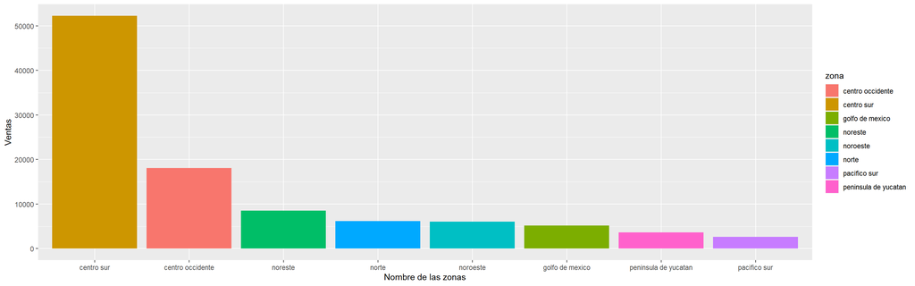

```r
gbarra <- ggplot(datos1, aes(x = forcats::fct_infreq(zona), fill = zona)) +
geom_bar() +
xlab("Nombre de las zonas") +
ylab("Ventas")

gbarra
```

#De todos los estados de la zona centro sur, el que presenta mayor numero de ventas es la CDMX

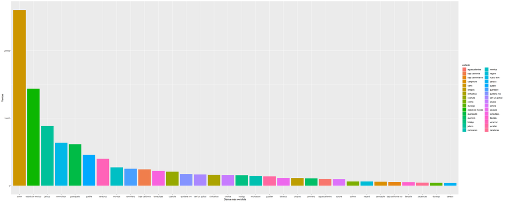

```r
estado_ventas <- ggplot(datos1, aes(x = forcats::fct_infreq(estado), fill = estado)) +
geom_bar() +
xlab("Gama mas vendida") +
ylab("Ventas")

estado_ventas
```

#Se puede observar que la gama alta es la presenta mayor numero de ventas

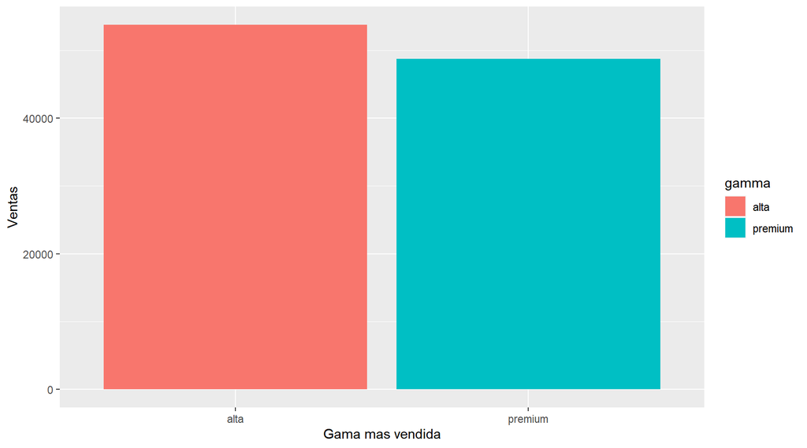

```r
gama_mas_vendida <- ggplot(datos1, aes(x = forcats::fct_infreq(gamma), fill = gamma)) +
geom_bar() +
xlab("Gama mas vendida") +
ylab("Ventas")

gama_mas_vendida
```

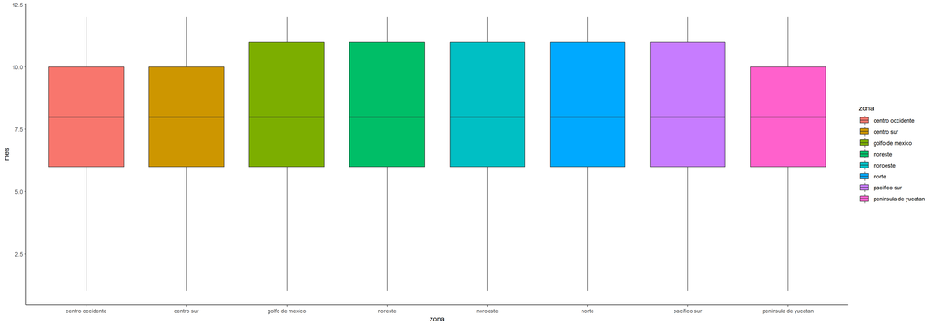

```r
ventastiempo <- ggplot(datos1, aes(x = zona, y = mes, fill=zona)) +
geom_boxplot(outlier.colour="red", outlier.shape=8, outlier.size=8)+
theme_classic()
ventastiempo
```

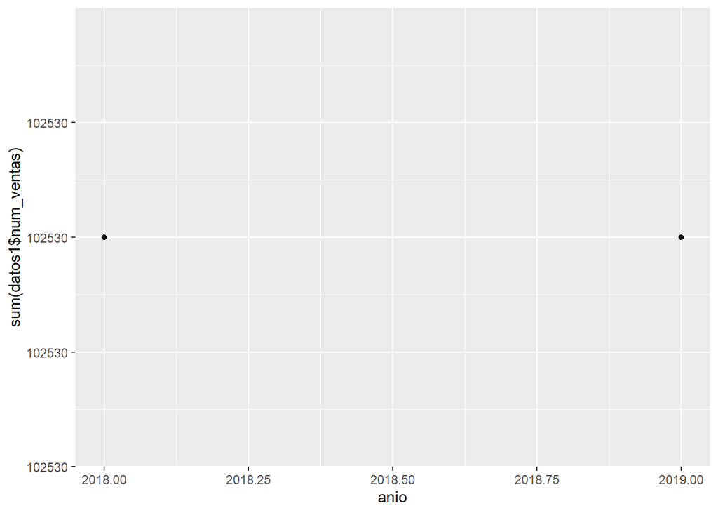

```r
ventasanio <- datos1%>%filter(gamma=="premium")
ggplot(ventasanio, aes(x = anio, y = sum(datos1$num_ventas))) +
geom_point()
```

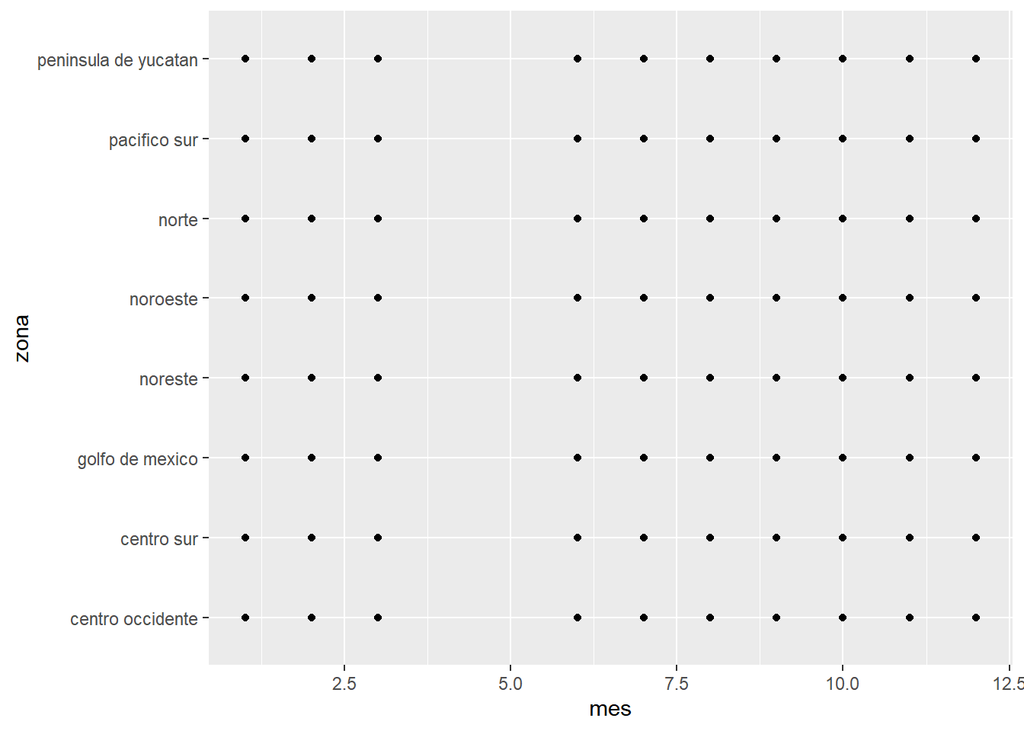

```r
gamma <- ggplot(datos1, aes(x = mes, y = zona)) +
geom_point()
gamma
```

[figure not shown]

```r
costop <- ggplot(datos1, aes(x = zona, y = num_ventas, fill=num_ventas)) +
geom_boxplot(outlier.colour="red", outlier.shape=8, outlier.size=8)+
theme_classic()
costop
```